# archivist and GitHub integration: archivist.github

Use case with RTCGA data

Marcin Kosiński

2016-31-01

[figure not shown]

Have you ever suffered because of the impossibility of reproducing graphs, tables or analysis results in R? Have you ever bothered yourself for not being able to share R objects (i.e. plots or final analysis models) within your reports, posters or articles? Or maybe simply you have too many objects you can’t manage to store in a convenient and handy way? Now you can share partial results of analysis, provide hooks to valuable R objects within articles, manage analysis results and restore objects’ pedigree with `archivist` package and it’s extension `archivist.github`. All automatically through GitHub without closing RStudio. If you are tired of archiving results by yourself, then read this tutorial.

# 1 Introduction

Open science needs not only reproducible research but also accessible final and partial results.

```r
library(archivist.github)
# described functionalities are implemented in the 2.0 version or achivist and 0.1 of archivist.github
# devtools::install_github('MarcinKosinski/archivist.github')
# install.packages('archivist.github')
```

The `archivist` is an R package for data analysis results management, which helps in managing, sharing, storing, linking and searching for R objects. The `archivist` package automatically retrieves the object’s meta-data and creates a rich structure that allows for easy management of calculated R objects. It also extends the reproducible research paradigm by creating new ways to retrieve and validate previously calculated objects.

This use case describes how `archivist` can be integrated with [GitHub](https://github.com) so that one can share (partial) results of his analysis in a more automatic and simpler way. GitHub is a platform on which collaborators can share their analysis code, figures and reports. It is also possible to share `R` objects which are crucial to the analysis or which calculations took a great amount of time or required a special software. Such objects are referred as *artifacts*. One might be only interested in a partial or final result without executing the whole analysis, which sometimes might be impossible due to lack of software, changes in `R` packages or simply takes to much time. If you are not using any version control system (like Git, hence GitHub), then get motivated [here](http://www.howtogeek.com/180167/htg-explains-what-is-github-and-what-do-geeks-use-it-for/) and [here](http://www.makeuseof.com/tag/git-version-control-youre-developer/).

The `archivist` is a tool that makes sharing `R` objects more convenient and transparent. Such objects can even be added to StackOverfow questions to improve providing reproducible examples (like [here](http://stackoverflow.com/questions/29653816/is-there-a-way-to-add-legend-next-to-a-dygraph-in-r-not-exactly-on-the-plot)).

# 2 Working with GitHub repository

GitHub API `OAuth` open autorization and `archivist.github` functions that are integrated with GitHub are described in an `R` documentation page accesed with `?agithub`. Information below provides broader explanation. New functions from `archivist.github` extension can be seen in below workflow

[figure not shown]

## 2.1 `OAuth` open autorization

To start sharing code and analysis results on GitHub a data scientist needs to create a repository on GitHub first. It can be done manually under this link https://github.com/new or one can use the `createGitHubRepo()` function to do this automatically. The `createGitHubRepo()` function integrates with the [GitHub API](https://developer.github.com/v3/) which enables performing operation on GitHub with a *simple* `curl` ([`"see URL"`](https://en.wikipedia.org/wiki/CURL)) - requests (if a data scientist comes with an IT background it’s easy, but when he’s background is different it is not so obvious). If you haven’t worked earlier with API and are wondering why they are so important and broadly used, then get keen on [here](http://readwrite.com/2013/09/19/api-defined).

Working with GitHub API requires creating a simple developer application (you can create it under this link https://github.com/settings/applications/new) which will be used to authenticate your `curl` requests (created via [`httr`](https://github.com/hadley/httr) package). It can be done once to benefit from it in future work. When application is created, one will have to copy its `Client ID` and `Client Secret` to authorize his computer with this application by running

```r
library(httr)
myapp <- oauth_app("github",
                   key = app_key,
                   secret = app_secret)
github_token <- oauth2.0_token(oauth_endpoints("github"),
                               myapp,
                               scope = c("public_repo",
                                         "delete_repo"))
# or use wrapper for
authoriseGitHub(ClientID, ClientSecret)
```

The above command created a `github_token` that uses `OAuth` open autorization system.

> OAuth allows notifying a resource provider (e.g. Facebook) that the resource owner (e.g. you) grants permission to a third-party (e.g. a Facebook Application) access to their information (e.g. the list of your friends).

More about `OAuth` is explained in that [StackOverflow answer](http://stackoverflow.com/a/4201618/3857701).

The `scope` parameter in the `oauth2.0_token` function lets you specify exactly what type of access you need. Scopes *limit* access for `OAuth` tokens. They do not grant any additional permission beyond that the user already has. In this example we granted read/write access to code, commit statuses, collaborators, and deployment statuses for public repositories and organizations, which are required for starring public repositories (`public_repo`). We also granted access to delete adminable repositories (`delete_repo`). More possible values of `scope` for GitHub API `OAuth` token can be found in [this table](https://developer.github.com/v3/oauth/#scopes).

## 2.2 Create or clone your repository

When `github_token` is created one can set it up as a global `github_token` visible for most `archivist` functions with

```r
aoptions("github_token", github_token)
```

```
<Token>
<oauth_endpoint>
 authorize: https://github.com/login/oauth/authorize
 access:    https://github.com/login/oauth/access_token
<oauth_app> github
  key:    1fab1e77d27079c0717d
  secret: <hidden>
<credentials> access_token, scope, token_type
---
```

```r
aoptions("user", user) # user = 'MarcinKosinski'
```

```
[1] "MarcinKosinski"
```

```r
invisible(aoptions("password", password))
```

What is more, one can specify GitHub’s `user.name` and `user.password` globally, so that future integration with Git/GitHub (i.e. commits or pushes) can be performed (with the great power of [`git2r`](https://github.com/ropensci/git2r) package).

One can create GitHub’s repository consisting of the `archivist`-like `Repository` of artifacts with

```r
createGitHubRepo(repo = "Gallery", default = TRUE)
```

```
[1] "MarcinKosinski"
```

```r
# -> https://github.com/MarcinKosinski/Gallery
```

`Repository` is a folder with an SQLite database stored in a file named `backpack.db` and a subdirectory named `gallery` with collection of objects saved as `.rda` files. To learn more about it visit [`archivist's` Wiki](https://github.com/pbiecek/archivist/wiki/archivist-package-Repository) or run in `R` console `?archivist::Repository`.

The `default = TRUE` option sets `Repository` under link `https://github.com/user.name/repo` as a visible default `Repository` for future `archivist.github` functions. In this way one won’t need to pass additional parameters to every functions’ calls.

If one already has a GitHub repository with `archivist` Repository it can be cloned and set as default.

```r
# eval = FALSE - this line is not evaluated in this tutorial
cloneGitHubRepo(repoURL = 'https://github.com/MarcinKosinski/Museum/',
                repoDir = any_local_path_or_NULL,
                default = TRUE)
```

When the option `default = TRUE` is used in the above functions, then the global parameters `repo` and `user` start being visible for the `achivist.github` functions. One can check if the parameter is set globally for the `archivist's` functions

```r
aoptions('repo')
```

```
[1] "Gallery"
```

```r
aoptions('user')
```

```
[1] "MarcinKosinski"
```

The globally set `Repository` stored on GitHub is synchronized with a Local `Repository` that can be set (or is already set when `default = TRUE`) in `repoDir` parameter

```r
aoptions('repoDir')
```

```
[1] "Gallery"
```

If a user did not specify the `repoDir` argument, during the `Repostiory` creation with `createGitHubRepo()`, it is by default set to the same value as `repo` parameter.

## 2.3 Archiving and exploring example

Now, when GitHub and `archivist` `Repositories` are created, one can archive and share artifacts (crucial objects) with `archive` function which also allows to emb a hook to the artifact in the report. We are creating `.html` report in [`rmarkdown`](http://rmarkdown.rstudio.com/), so the default markdown formating for hook is used. For $\LaTeX$-like hooks use `format = “latex”.

Let us prepare a linear model with `iris` data

```r
iris.lm.model <- lm(Sepal.Length ~ Sepal.Width + Petal.Length + Petal.Width,
                                        data= iris)
```

and let’s archive the desired model automatically to the created `Repository` (https://github.com/MarcinKosinski/Gallery).

```r
# results = 'asis' - so that a text can be understood as a URL
archive(iris.lm.model, alink = TRUE)
```

[`archivist::aread('MarcinKosinski/Gallery/caab8f8e72045c93f92091aebcb74f2d')`](https://raw.githubusercontent.com/MarcinKosinski/Gallery/master/gallery/caab8f8e72045c93f92091aebcb74f2d.rda)

The `archive` function created a hook to the artifact. One can download this shared artifact by clicking the link or by copying and pasting it’s value to R console. It is a great way to provide a hook to the figures in posters or publications that are really an `R` objects (such as `ggplot` class). The object named `iris.lm.model` was archived to the GitHub (and synchronized Local) `Repository`. This is the final implementation of the `archive` prototype we presented at the [BI FORUM](https://budapestbi2015.sched.org/event/4JA8/archivist-managing-data-analysis-results) conference in Budapest in Oct 2015.

One can check that the artifact is really on GitHub with

```r
showRemoteRepo(repo = 'Gallery', user = 'MarcinKosinski')
```

```
                           md5hash                             name         createdDate
1 caab8f8e72045c93f92091aebcb74f2d                    iris.lm.model 2016-02-24 19:12:15
2 b0f870835c546853b70f921f57e100b4 b0f870835c546853b70f921f57e100b4 2016-02-24 19:12:15
3 7a761a2ae54f3d90060a9f6ca04b3506 7a761a2ae54f3d90060a9f6ca04b3506 2016-02-24 19:12:15
```

```r
# showRemoteRepo() would also work since `user` and `repo` are set gobally
```

The first row corresponds to the archived artifact, the second one corresponds to the archived data extracted from an artifact. The `md5hash` column specifies which MD5 hash (see `?digest::digest`) the artifacts has been connected with. Artifacts are archived along with a special attribute named `md5hash`. For each artifact, `md5hash` is a unique string of length 32 that is produced by `digest{digest}` function which uses a cryptographical MD5 hash algorithm. The `md5hash` of each artifact archived to the `Repository` is also saved on the `Repository` along with the artifact’s `Tags` (see [`Tags` on `archivist` WIKI](https://github.com/pbiecek/archivist/wiki/archivist-package---Tags)). It enables to distinguish objects in the `Repository` and facilitates searching and loading them.

Each artifact can be archived with its unique `Tags` which are attributes of an artifact. They can be the artifact’s name, class or archiving date. Furthermore, for various artifact’s classes different `Tags` are available. Let us archive one more artifact to explain how various `Tags` can be extracted during archiving and let us even specify our own `userTags`.

```r
# results = 'asis' - so that a text can be understood as a URL
iris.lm.model.smry <- summary(iris.lm.model)
archive(iris.lm.model.smry, alink = TRUE,
        userTags = paste0("summaryOf:", digest::digest(iris.lm.model)))
```

[`archivist::aread('MarcinKosinski/Gallery/067896394acf47242b30b07ac300dc48')`](https://raw.githubusercontent.com/MarcinKosinski/Gallery/master/gallery/067896394acf47242b30b07ac300dc48.rda)

One can check what `Tags` have been extracted so far

```r
Sys.sleep(300)
# After a commit sometimes GitHub does not react so fast
# so we need to give it a time.
# Immiediate access depends on github.com performance
showRemoteRepo(method = "tags")[, -3]
```

```
                           artifact                                           tag
1  caab8f8e72045c93f92091aebcb74f2d                                    format:rda
2  caab8f8e72045c93f92091aebcb74f2d                            name:iris.lm.model
3  caab8f8e72045c93f92091aebcb74f2d                                      class:lm
4  caab8f8e72045c93f92091aebcb74f2d                          coefname:(Intercept)
5  caab8f8e72045c93f92091aebcb74f2d                          coefname:Sepal.Width
6  caab8f8e72045c93f92091aebcb74f2d                         coefname:Petal.Length
7  caab8f8e72045c93f92091aebcb74f2d                          coefname:Petal.Width
8  caab8f8e72045c93f92091aebcb74f2d                                        rank:4
9  caab8f8e72045c93f92091aebcb74f2d                               df.residual:146
10 caab8f8e72045c93f92091aebcb74f2d                      date:2016-02-24 19:12:15
11 b0f870835c546853b70f921f57e100b4                                    format:rda
12 caab8f8e72045c93f92091aebcb74f2d session_info:b0f870835c546853b70f921f57e100b4
13 7a761a2ae54f3d90060a9f6ca04b3506                                    format:rda
14 7a761a2ae54f3d90060a9f6ca04b3506                                    format:txt
```

[output cut: 18 more lines]

or more convenient form for [`dplyr`](https://github.com/hadley/dplyr) grouping and aggregation operations (thanks to `@eliotmcintire` for the suggestion and `@wchodor` for the implementation - [issue](https://github.com/pbiecek/archivist/issues/91)).

```r
splitTagsRemote(repo = 'Gallery', user = 'MarcinKosinski')[,-4]
```

```
                           artifact        tagKey                         tagValue
1  caab8f8e72045c93f92091aebcb74f2d        format                              rda
2  caab8f8e72045c93f92091aebcb74f2d          name                    iris.lm.model
3  caab8f8e72045c93f92091aebcb74f2d         class                               lm
4  caab8f8e72045c93f92091aebcb74f2d      coefname                      (Intercept)
5  caab8f8e72045c93f92091aebcb74f2d      coefname                      Sepal.Width
6  caab8f8e72045c93f92091aebcb74f2d      coefname                     Petal.Length
7  caab8f8e72045c93f92091aebcb74f2d      coefname                      Petal.Width
8  caab8f8e72045c93f92091aebcb74f2d          rank                                4
9  caab8f8e72045c93f92091aebcb74f2d   df.residual                              146
10 caab8f8e72045c93f92091aebcb74f2d          date              2016-02-24 19:12:15
11 b0f870835c546853b70f921f57e100b4        format                              rda
12 caab8f8e72045c93f92091aebcb74f2d  session_info b0f870835c546853b70f921f57e100b4
13 7a761a2ae54f3d90060a9f6ca04b3506        format                              rda
14 7a761a2ae54f3d90060a9f6ca04b3506        format                              txt
```

[output cut: 18 more lines]

```r
library(dplyr)
splitTagsRemote(repo = 'graphGallery', user = 'pbiecek') %>%
    group_by(tagKey) %>%
    summarise(count = n()) %>%
    arrange(desc(count))
```

```
Source: local data frame [13 x 2]

         tagKey count
          (chr) (int)
1       varname  1229
2         class   508
3          date   500
4      coefname   493
5          name   299
6           LHS   233
7           RHS   233
8  relationWith    35
9        format    15
10       labelx     7
11       labely     7
12 session_info     4
13         data     3
```

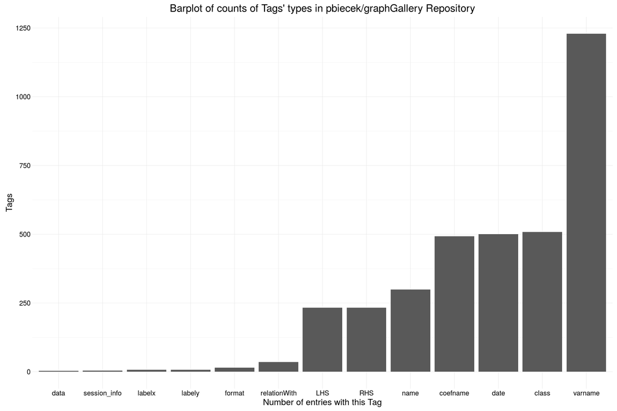

```r
library(ggplot2)
splitTagsRemote(repo = 'graphGallery', user = 'pbiecek') %>%
    group_by(tagKey) %>%
    summarise(count = n()) %>%
    arrange(desc(count)) %>%
    ggplot(aes(reorder(tagKey, count, max), count)) +
    geom_bar(stat = "identity") +
    theme_minimal() + xlab('Number of entries with this Tag') + ylab('Tags') +
    ggtitle('Barplot of counts of Tags\' types in pbiecek/graphGallery Repository')
```

Extracting `Tags` for a specific artifact can be done with

```r
getTagsRemote(md5hash = digest::digest(iris.lm.model.smry),
              tag = "", user = 'MarcinKosinski', repo = 'Gallery' ) %>% data.frame()
```

```
                                               .
1                                     format:rda
2                        name:iris.lm.model.smry
3                               class:summary.lm
4                                   sigma:0.3145
5                                           df:4
6                                         df:146
7                                     R^2:0.8586
8                            adjusted R^2:0.8557
9                               fstatistic:295.5
10                               fstatistic.df:3
11                             fstatistic.df:146
12                      date:2016-02-24 19:12:48
13    summaryOf:caab8f8e72045c93f92091aebcb74f2d
14 session_info:dfb4355fdd4baa980368a13c4bf8ef3f
```

After the `Repository` is created and the crucial objects are achived anyone can explore public `archivist` `Repository` shared on GitHub. Knowing the object’s `md5hash` one can download it with

```r
loadFromRemoteRepo(md5hash = digest::digest(iris.lm.model.smry),
                   value = TRUE) -> ddl.iris.lm.model.smry
ddl.iris.lm.model.smry$sigma
```

```
[1] 0.3145491
```

or can explore `Repository` for various objects using their `Tags`.

When one is interested in all objects of class `lm` that were created with `Species` explanatory variable (with `versicolor` factor level) in [`pbiecek/graphGallery`](https://github.com/pbiecek/graphGaller) repository, then one might download them, extract R-squared statistics and coefficients, bind them in one data frame and sort rows by R-squared statistics to get the best model with the following code

```r
mm <- asearch(patterns = c('class:lm',
                     'coefname:Speciesversicolor'),
        repo = 'pbiecek/graphGallery')

mm %>%
  lapply(function(x) {
    c(r.squared = summary(x)$r.squared,
      x$coef) %>%
      # extract coeffs and R-squared statistic
      t %>%
      as.data.frame # transpose for binding
  }) %>%
  do.call(dplyr::bind_rows, .) %>% # apply bind_rows to all list elements
  cbind(data.frame(md5hash = names(mm))) %>%
  arrange(r.squared) %>% # arrange rows by r.squared
    unique() %>%
        select(-Sepal.Length) # to fit in the output html
```

```
  r.squared (Intercept) Speciesversicolor Speciesvirginica                          md5hash
1 0.6187057    5.006000          0.930000         1.582000 0e213ac68a45b6cd454d06b91f991bc7
2 0.6187057    5.006000          0.930000         1.582000 e58d2f9d50b67ce4d397bf015ec1259c
3 0.9413717    1.462000          2.798000         4.090000 0a82efeb8250a47718cea9d7f64e5ae7
4 0.9413717    1.462000          2.798000         4.090000 378237103bb60c58600fe69bed6c7f11
5 0.9413717    1.462000          2.798000         4.090000 7f11e03539d48d35f7e7fe7780527ba7
6 0.9413717    1.462000          2.798000         4.090000 c1b1ef7bcddefb181f79176015bc3931
7 0.9604273    1.462000          2.507231         3.509429 990861c7c27812ee959f10e5f76fe2c3
8 0.9748944   -1.702342          2.210138         3.090002 2a6e492cb6982f230e48cf46023e2e4f
```

This might be used to extract the most valuable model (in terms of R-squared statistics) within the `Repository`. Imagine a `Repository` with hundreds of classification models and their potentional blends, where each of them is archived with additional `Tags` describing their performance. One gained a great tool to search for the best classifier within dozens of models.

If one would like to extract only `md5hashes` for given `Tags` instead of whole artifacts, then `searchInRemoteRepo()` function can be used

```r
searchInRemoteRepo(pattern = 'name', fixed = FALSE, repo = 'graphGallery', user = 'pbiecek') %>% length
```

```
[1] 51
```

```r
# return md5hashes of artifacts that have a tag containing a substring `name`
searchInRemoteRepo(pattern = c('class:ggplot', 'class:lm'),
                        repo = 'graphGallery', user = 'pbiecek',
                        intersect = FALSE) %>% length
```

```
[1] 15
```

Desired artifacts can even be copied to our Local `Repository` from GihHub

```r
searchInRemoteRepo(pattern = c('class:ggplot', 'class:lm'),
                        repo = 'graphGallery', user = 'pbiecek',
                        intersect = FALSE)[1:3] %>%
    copyRemoteRepo(md5hashes = ., user = 'pbiecek', repo = 'graphGallery',
                   repoTo = 'Gallery')
showLocalRepo(repoDir = 'Gallery')[, -3]
```

```
                           md5hash                                    name
1 caab8f8e72045c93f92091aebcb74f2d                           iris.lm.model
2 b0f870835c546853b70f921f57e100b4        b0f870835c546853b70f921f57e100b4
3 7a761a2ae54f3d90060a9f6ca04b3506        7a761a2ae54f3d90060a9f6ca04b3506
4 067896394acf47242b30b07ac300dc48                      iris.lm.model.smry
5 dfb4355fdd4baa980368a13c4bf8ef3f        dfb4355fdd4baa980368a13c4bf8ef3f
6 b6f183dfd0efdc8c33fa89b9038716c5                                      pl
7 b6f183dfd0efdc8c33fa89b9038716c5                                      pl
8 fcd70d55b874201d2bece12f591a2ec4                                      pl
9 4cc15e46b6008f5867a92364fe36e835 qplot(time, arr_delay, data = per_hour)
```

# 3 Advanced example with RTCGA

Let’s have a look at more advanced example. Suppose we would like to create a similar graph to this one but with slightly different input data.

```r
aread('MarcinKosinski/coxphSGD/db03267b063709277e50bd4c0c1ddb04') -> survival.egfr.plot
class(survival.egfr.plot)
```

```
[1] "tableAndPlot" "list"
```

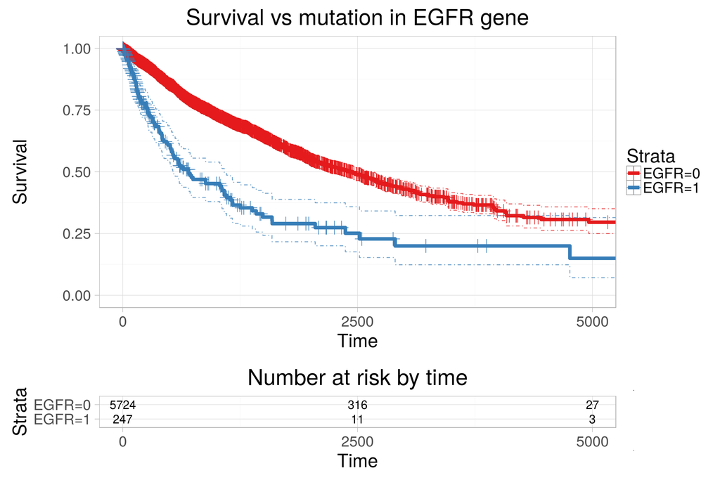

```r
# this object is a result of survMisc:::autoplot.survfit function which mainly
# produces a list containing 2 ggplot objects

survival.egfr.plot$plot <- survival.egfr.plot$plot +
    ggtitle('Survival vs mutation in EGFR gene')  # the previous title was in polish
survMisc::autoplot(survival.egfr.plot) # it will plot survival plot and risk set table
```

The plot presents the Kaplan-Meier estimates of the survival curves for patients suffering from cancer, divided into 2 groups: one with a mutation in EGFR gene (`EGFR=1`) and the other without it (`EGFR=0`). The mutation can be a deletion, amplification etc..

## 3.1 About RTCGA

[figure not shown]

The data used to produce previous plot came from [*The Cancer Genome Atlas*](http://cancergenome.nih.gov/abouttcga) Study.

> The Cancer Genome Atlas (TCGA) is a comprehensive and coordinated effort to accelerate our understanding of the molecular basis of cancer through the application of genome analysis technologies, including large-scale genome sequencing.

The download of data through `R` is possible with the [`RTCGA`](http://bioconductor.org/packages/RTCGA/) package but most of useful datasets are already converted and available in the [`RTCGA family`](http://github.com/RTCGA/) of `R` data packages.

## 3.2 Partial results archiving and objects’ pedigree restoration

I am a really keen on long forward-pipe operations so I’ll try my best to create a good one, which will join information about clinical state of a patient with the information about the existence of an PIK3CA gene mutations (which is the most common for BRCA) and the information about expression of a gene TP53 (which is believed to be a guardian of the genome).

```r
library(RTCGA.rnaseq); data(BRCA.rnaseq) # information about genes' expressions
library(RTCGA.mutations); data(BRCA.mutations) # information about genes' mutations
library(RTCGA.clinical); data(BRCA.clinical) # patients' clinical data

aoptions('silent', TRUE) # This sets `silent=TRUE` in saveToRepo which is used by %a% . There will be no warning printed about archiving the same artifact or it's data twice.
```

```
[1] TRUE
```

```r
BRCA.rnaseq %a%
    select(`TP53|7157`, bcr_patient_barcode) %a%
    # bcr_patient_barcode contains a key to merge patients between various datasets
    rename(TP53 = `TP53|7157`) %a%
    filter(substr(bcr_patient_barcode, 14, 15) == "01" ) %a%
    # 01 at the 14-15th position tells these are cancer sample
    mutate(bcr_patient_barcode = substr(as.character(bcr_patient_barcode),1,12)) ->
    # in clinical info bcr_patient_barcode is only of length 12
    BRCA.rnaseq.TP53

BRCA.mutations %a%
    select(Hugo_Symbol, bcr_patient_barcode) %a%
    # Hugo_symbol tells to which gene the row corresponds.
    # Ff the rows exist for a gene, this means there was a mutation for this patient for this gene.
    filter(nchar(bcr_patient_barcode)==15) %a%
    # sometime there are inproper lengths of this code
    filter(substr(bcr_patient_barcode, 14, 15)=="01") %a%
    # 01 at the 14-15th position tells these are cancer sample
    filter(Hugo_Symbol == 'PIK3CA') %a%
    # we are interested only in the mutations of PIK3CA
    unique() %a%
  # sometimes there are few mutations in the same gene
    mutate(bcr_patient_barcode = substr(as.character(bcr_patient_barcode),1,12)) ->
    # in clinical info bcr_patient_barcode is only of length 12
    BRCA.mutations.PIK3CA

BRCA.clinical %a%
    select(patient.bcr_patient_barcode,
           patient.vital_status, # information whether patient is still alive
           patient.days_to_last_followup, # how many days has patient been observed if he is alive
           patient.days_to_death) %a% # how many days has patient been observed if he has passed away
    mutate(bcr_patient_barcode = toupper(as.character(patient.bcr_patient_barcode))) %a%
    # in clinical datasets the key column is in lower case and with different name
    mutate(status = ifelse(as.character(patient.vital_status) == "dead",1,0),
           times = ifelse(
                        !is.na(patient.days_to_last_followup),
                        as.numeric(as.character(patient.days_to_last_followup)),
                        as.numeric(as.character(patient.days_to_death))
            )) %a%
    # if the patient does not have a days_to_last_followup time this means
    # he has days_to_death time
    filter(!is.na(times)) %a%
    # sometime patient does not have any time
    filter(times > 0) -> BRCA.clinical.survival
    # sometimes by mistkae patients have non-positive times (few cases)

BRCA.rnaseq.TP53 %a%
    left_join(y = BRCA.mutations.PIK3CA,
                        by = "bcr_patient_barcode") %a%
    left_join(y = BRCA.clinical.survival,
                        by = "bcr_patient_barcode") %a%
    mutate(TP53_HighExpr = ifelse(TP53 >= median(TP53), "1", "0")) %a%
    mutate(PIK3CA_Mut = as.integer(!is.na(Hugo_Symbol))) %a%
    select(times, status, TP53_HighExpr, PIK3CA_Mut)  -> BRCA.2survfit
```

And then one can print artifact’s history/pedigree with the `ahistory()` function that works in 3 variants

```r
ahistory(BRCA.rnaseq.TP53) # regular format
```

```
   env[[nm]]                                                                           [63678e012c5b7f40966c32eec91f828b]
-> select(`TP53|7157`, bcr_patient_barcode)                                            [4a85ce61229dd743b911d7edab0310b3]
-> rename(TP53 = `TP53|7157`)                                                          [103f2b82c41956e9f6437b3a0cd68679]
-> filter(substr(bcr_patient_barcode, 14, 15) == "01")                                 [1da5a026aae19e0d0467ba3773679e28]
-> mutate(bcr_patient_barcode = substr(as.character(bcr_patient_barcode),     1, 12))  [2001f888c6262e30154688876c91cc50]
```

```r
# additional chunk options: results='asis'
ahistory(BRCA.mutations.PIK3CA, format = "kable") # uses knitr::kable()
```

|  | call | md5hash |
| --- | --- | --- |
| 7 | env[[nm]] | b2c7c1b633de515d59c9af635805ed29 |
| 6 | select(Hugo_Symbol, bcr_patient_barcode) | 9e4936fa0de8ca0ebc50fa310e845473 |
| 5 | filter(nchar(bcr_patient_barcode) == 15) | fc93fb6885a6387d1495ce0a6456d4f6 |
| 4 | filter(substr(bcr_patient_barcode, 14, 15) == “01”) | 2cee0b51527271264f70aa91ee4f33e5 |
| 3 | filter(Hugo_Symbol == “PIK3CA”) | e9a920ae11aa23e0b842f5e64c446a9d |
| 2 | unique() | 194214bafe8287c73f44bd660b74e199 |
| 1 | mutate(bcr_patient_barcode = substr(as.character(bcr_patient_barcode), 1, 12)) | c280e394539be64c73ea022b9ea9fa05 |

```r
ahistory(BRCA.2survfit, format = "kable", alink = TRUE ) # give hooks to objects
```

|  | call | md5hash |
| --- | --- | --- |
| 10 | env[[nm]] | [63678e012c5b7f40966c32eec91f828b](https://raw.githubusercontent.com/MarcinKosinski/Gallery/master/gallery/63678e012c5b7f40966c32eec91f828b.rda) |
| 9 | select(`TP53\|7157`, bcr_patient_barcode) | [4a85ce61229dd743b911d7edab0310b3](https://raw.githubusercontent.com/MarcinKosinski/Gallery/master/gallery/4a85ce61229dd743b911d7edab0310b3.rda) |
| 8 | rename(TP53 = `TP53\|7157`) | [103f2b82c41956e9f6437b3a0cd68679](https://raw.githubusercontent.com/MarcinKosinski/Gallery/master/gallery/103f2b82c41956e9f6437b3a0cd68679.rda) |
| 7 | filter(substr(bcr_patient_barcode, 14, 15) == “01”) | [1da5a026aae19e0d0467ba3773679e28](https://raw.githubusercontent.com/MarcinKosinski/Gallery/master/gallery/1da5a026aae19e0d0467ba3773679e28.rda) |
| 6 | mutate(bcr_patient_barcode = substr(as.character(bcr_patient_barcode), 1, 12)) | [2001f888c6262e30154688876c91cc50](https://raw.githubusercontent.com/MarcinKosinski/Gallery/master/gallery/2001f888c6262e30154688876c91cc50.rda) |
| 5 | left_join(y = BRCA.mutations.PIK3CA, by = “bcr_patient_barcode”) | [8a615a0954e03d11a0ef2d705c59766e](https://raw.githubusercontent.com/MarcinKosinski/Gallery/master/gallery/8a615a0954e03d11a0ef2d705c59766e.rda) |
| 4 | left_join(y = BRCA.clinical.survival, by = “bcr_patient_barcode”) | [a8b097ee7010673b2078e8c4d47079df](https://raw.githubusercontent.com/MarcinKosinski/Gallery/master/gallery/a8b097ee7010673b2078e8c4d47079df.rda) |
| 3 | mutate(TP53_HighExpr = ifelse(TP53 >= median(TP53), “1”, “0”)) | [73eef46c8dfe31a99beb47ee6edfb4f3](https://raw.githubusercontent.com/MarcinKosinski/Gallery/master/gallery/73eef46c8dfe31a99beb47ee6edfb4f3.rda) |
| 2 | mutate(PIK3CA_Mut = as.integer(!is.na(Hugo_Symbol))) | [7a4625c0521157f81a3db11ddd196779](https://raw.githubusercontent.com/MarcinKosinski/Gallery/master/gallery/7a4625c0521157f81a3db11ddd196779.rda) |
| 1 | select(times, status, TP53_HighExpr, PIK3CA_Mut) | [684d08dfe5d3a6dff389ad210f69aa36](https://raw.githubusercontent.com/MarcinKosinski/Gallery/master/gallery/684d08dfe5d3a6dff389ad210f69aa36.rda) |

```r
# Note that they are not yet available on GitHub,
# because the archiving was only to Local Repository.
```

### 3.2.1 Overloading `print()` function

The final data would be used to plot the Kaplan-Meier estimates of the survival curves with the use of `my.customized.km()` function.

```r
tail(BRCA.2survfit)
```

```
     times status TP53_HighExpr PIK3CA_Mut
1088  1550      0             1          0
1089   791      0             1          0
1090   292      0             1          0
1091   278      0             0          0
1092  3042      0             1          0
1093  2800      0             0          0
```

```r
BRCA.2survfit %>%
    select(TP53_HighExpr, PIK3CA_Mut, status) %>%
    table()
```

```
, , status = 0

             PIK3CA_Mut
TP53_HighExpr   0   1
            0 359 118
            1 298 161

, , status = 1

             PIK3CA_Mut
TP53_HighExpr   0   1
            0  35   9
            1  47  13
```

`my.customized.km()` function is based on [`survMisc`](https://cran.r-project.org/web/packages/survMisc/index.html) package, which was moved to CRAN archive suddenly. It’s implementation/body is too long to write it down here (and unnecessary) but can be imported to `R` with

```r
# Instead of whole md5hash an abbreviation can be specified.
# If more that one md5hash matches this abbrevation, then every corresponding artifact is loaded.
aread('MarcinKosinski/Museum/30efaaedb') -> my.customized.km
# or loadFromGithubRepo(md5hash = '30efaaedb', user = 'MarcinKosinski', repo = 'Museum')

my.customized.km('times', 'status', c('TP53_HighExpr', 'PIK3CA_Mut'), BRCA.2survfit,
                                 'Survival vs TP53 expression and mutations in PIK3CA') -> km_plot
class(km_plot)
```

```
[1] "tableAndPlot" "list"
```

One can even overload `print` function for a specific class to first perform `archive` operation, then to extract hook in the way that is compatible with the format of report and lastly to print the object. Original idea came from [here](https://github.com/pbiecek/archivist/issues/180) and [here](https://github.com/pbiecek/archivist/issues/74)

```r
print.tableAndPlot  <- function(x, ...) {
    saveToRepo(x) -> hash
    cat(alink(hash)) # uses globally set `user` and `repo`
    survMisc:::autoplot.tableAndPlot(x, ...)
}
# results = 'asis'
archive(print.tableAndPlot, commitMessage = 'print.tableAndPlot function', alink = TRUE)
```

[`archivist::aread('MarcinKosinski/Gallery/fcd394ab60e8c14545028ab8f68eb9bc')`](https://raw.githubusercontent.com/MarcinKosinski/Gallery/master/gallery/fcd394ab60e8c14545028ab8f68eb9bc.rda)

```r
# results = 'asis'
print(km_plot)
```

[`archivist::aread('MarcinKosinski/Gallery/41eb3f66d56dd9df86554c9ee6022b43')`](https://raw.githubusercontent.com/MarcinKosinski/Gallery/master/gallery/41eb3f66d56dd9df86554c9ee6022b43.rda)

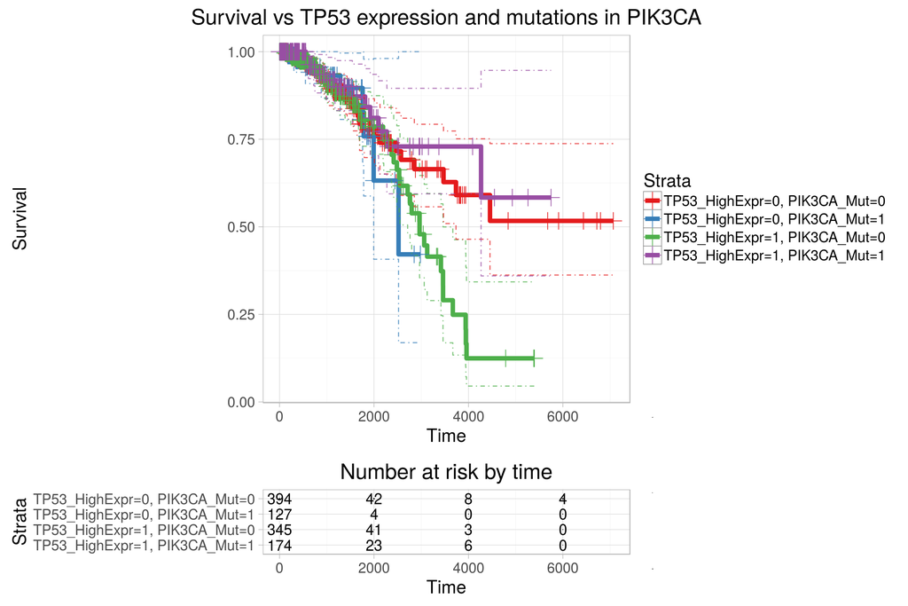

Easier version of this functionality is described in this Use Case about [addHookToPrint](https://cdn.rawgit.com/pbiecek/archivist/master/scripts/replicationScript.html).

### 3.2.2 Pushing Local `Repository` to GitHub

One might have noticed that `%a%` operator and `saveToLocalRepo()` function saved objects only to the Local `Repository` that is synchronized with GitHub. This is different to the `archive` function which archives to the Local and GitHub `Repository` simultaneously. It is possible to `push` (Git command) artifacts that are only present in the Local `Repository` to GitHub equivalent with `pushGitHubRepo` function

```r
# number of artifacts before push
searchInRemoteRepo(pattern = "name", fixed = FALSE) %>% length
```

```
[1] 2
```

```r
# one can check how many commits have been performed so far
length(jsonlite::fromJSON(rawToChar(GET('https://api.github.com/repos/MarcinKosinski/Gallery/commits')$content))$sha)
```

```
[1] 4
```

```r
pushGitHubRepo() # uses globally set parametrs when none are provided
# number of artifacts after push
Sys.sleep(300) # to be sure my request isn't faster than GitHub platform after push
searchInRemoteRepo(pattern = "name", fixed = FALSE) %>% length
```

```
[1] 30
```

```r
# one can check how many commits have been performed so far
length(jsonlite::fromJSON(rawToChar(GET('https://api.github.com/repos/MarcinKosinski/Gallery/commits')$content))$sha)
```

```
[1] 5
```

This operation might be troublesome when other collaborator has pushed his changes to the remote GitHub `Repository`. Sometimes it’s better to first `pull` (Git command) changes (new artifacts) from the synchronized Github `Repository`. Working with too many collaborators may occure in Git conflicts in the `backpack.db` file. If you have any ideas or suggestions how can this be handle please write in [this issue](https://github.com/pbiecek/archivist/issues/146). `pullGitHubRepo()` and `pushGitHubRepo()` both have additional parameter `...` enabling passing more sophisticated options to `git2r::pull` and `git2r::push` when more complex conflicts occure.

# 4 `Repository` and `gallery` summaries

It is also possible to create a summary of `gallery` folder, which in other words mean a summary of each artifact stored in `Repository`. Special `createMDGallery()` function creates an `.md` file with hooks to artifacts, their list of `Tags` and if possible their miniature in a form of a `.png` file. By now only plots like `lattice` and `ggplot` object’s are saved also with their `.png` miniature and only for those objects mianiture can be added to `gallery` summary.

In the below example we extract `gallery` summary to the `README.md` file which will be appended with additional lines of the summary.

```r
createMDGallery(output = 'Gallery/README.md', addTags = TRUE, addMiniature = TRUE)
```

The output of this function can be seen in the `README` of `Gallery` `Repository` (https://github.com/MarcinKosinski/Gallery) in which we are working in this tutorial, after it’ll be pushed to GitHub with

```r
pushGitHubRepo(files = 'README.md')
```

The results is [here](https://github.com/MarcinKosinski/Gallery/blob/master/README.md) and few interesting `gallery` summaries are [here](https://github.com/pbiecek/Eseje/tree/master/arepo) and [here](https://github.com/pbiecek/archivist/issues/144#issuecomment-169793283).

The `archivist` package also provides `Repository` summary with `summaryGithubRepo` function. This is rather old but still relevant.

```r
summaryRemoteRepo()
```

```
Number of archived artifacts in Repository:  30
Number of archived datasets in Repository:  1
Number of various classes archived in Repository:
              Number
lm                1
summary.lm        1
ggplot            3
data.frame       23
function          1
tableAndPlot      1
list              1
Saves per day in Repository:
            Saves
2016-02-24    32
2014-08-21     2
2014-09-03     1
```

# 5 Repository deletion

One can easily delete existing Local and GitHub `Repository`. For GitHub one can delete only `archivist`-like `Repository` (gallery folder and `backpack.db` file) by default or the whole GitHub-repository with `deleteRoot = TRUE`. (Yes, I have used those many times while writing this Use Case :)).

```r
# eval = FALSE
deleteLocalRepo(repoDir = 'Gallery', deleteRoot = TRUE)
deleteGitHubRepo('Gallery', deleteRoot = TRUE)
```

# 6 Feedback and Notes

By now archivist extract extra `Tags` only for such object’s classes

```r
# http://stackoverflow.com/a/11005886/3857701
methodsTable <- ls(.__S3MethodsTable__.,
                   envir = asNamespace("archivist"),
                   all.names = TRUE)
grep('extractTags', methodsTable, value = TRUE) %>%
    data.frame(extracTags_methods =.) %>%
    pander::pandoc.table()
```

| extracTags_methods |
| --- |
| extractTags |
| extractTags.data.frame |
| extractTags.default |
| extractTags.ggplot |
| extractTags.glmnet |
| extractTags.htest |
| extractTags.lda |
| extractTags.lm |
| extractTags.partition |
| extractTags.qda |
| extractTags.summary.lm |
| extractTags.survfit |
| extractTags.trellis |
| extractTags.twins |

If you would like to create wrappers for [other classes](https://github.com/pbiecek/archivist/issues/162) please [open an issue](https://github.com/pbiecek/archivist/issues) or

[figure not shown]

even for other suggestions, comments or user requests like [integration with bitbucket](https://github.com/pbiecek/archivist/issues/178), [support for other languages](https://github.com/pbiecek/archivist/issues/179), [support for json/csv files](https://github.com/pbiecek/archivist/issues/181), [summary plots of the `Repository`](https://github.com/pbiecek/archivist/issues/147).

```
 setting  value
 version  R version 3.2.2 (2015-08-14)
 system   x86_64, linux-gnu
 ui       X11
 language English
 collate  pl_PL.UTF-8
 tz       <NA>
 date     2016-02-24

 package          * version      date       source
 acepack            1.3-3.3      2014-11-24 CRAN (R 3.2.0)
 archivist        * 2.0.1        2016-02-21 CRAN (R 3.2.2)
 archivist.github * 0.1          2016-02-24 CRAN (R 3.2.2)
 assertthat         0.1          2013-12-06 CRAN (R 3.2.0)
 bitops             1.0-6        2013-08-17 CRAN (R 3.2.0)
 chron              2.3-47       2015-06-24 CRAN (R 3.2.1)
 cluster            2.0.3        2015-07-21 CRAN (R 3.2.1)
 codetools          0.2-14       2015-07-15 CRAN (R 3.2.1)
 colorspace         1.2-6        2015-03-11 CRAN (R 3.2.2)
 combinat           0.0-8        2012-10-29 CRAN (R 3.2.0)
 curl               0.9.6        2016-02-17 CRAN (R 3.2.2)
 data.table         1.9.7        2015-12-29 Github (Rdatatable/data.table@405f115)
 DBI                0.3.1        2014-09-24 CRAN (R 3.2.2)
 devtools           1.10.0       2016-01-23 CRAN (R 3.2.2)
 digest             0.6.9        2016-01-08 CRAN (R 3.2.2)
 dplyr            * 0.4.3        2015-09-01 CRAN (R 3.2.2)
 evaluate           0.8          2015-09-18 CRAN (R 3.2.1)
 foreach            1.4.3        2015-10-13 CRAN (R 3.2.2)
 foreign            0.8-66       2015-08-19 CRAN (R 3.2.1)
 formatR            1.2.1        2015-09-18 CRAN (R 3.2.1)
 Formula            1.2-1        2015-04-07 CRAN (R 3.2.0)
 gam                1.12         2015-05-13 CRAN (R 3.2.0)
 ggbiplot           0.55         2015-09-23 Github (vqv/ggbiplot@7325e88)
 ggplot2          * 2.0.0        2015-12-18 CRAN (R 3.2.2)
 ggthemes           3.0.1        2016-01-10 CRAN (R 3.2.2)
 git2r              0.13.1       2015-12-10 CRAN (R 3.2.2)
 gridExtra          2.0.0        2015-07-14 CRAN (R 3.2.1)
 gtable             0.1.2        2012-12-05 CRAN (R 3.2.0)
 highr              0.5.1        2015-09-18 CRAN (R 3.2.1)
 Hmisc              3.17-1       2015-12-18 CRAN (R 3.2.2)
```

[output cut: 27 more lines]

```
 RTCGA            * 1.1.14       2016-02-24 Github (RTCGA/RTCGA@7d6d667)
 RTCGA.clinical   * 20151101.1.0 2016-02-22 Github (RTCGA/RTCGA.clinical@0239210)
 RTCGA.mutations  * 20151101.0.0 2016-02-22 Github (RTCGA/RTCGA.mutations@3c3b83b)
 RTCGA.rnaseq     * 20151101.0.0 2016-02-22 Github (RTCGA/RTCGA.rnaseq@196d7d2)
 rvest              0.3.1        2015-11-11 CRAN (R 3.2.2)
 scales             0.3.0        2015-08-25 CRAN (R 3.2.1)
 stringi            1.0-1        2015-10-22 CRAN (R 3.2.1)
 stringr            1.0.0        2015-04-30 CRAN (R 3.2.0)
 survival         * 2.38-3       2015-07-02 CRAN (R 3.2.1)
 survminer          0.2.0.9001   2016-02-24 local
 survMisc         * 0.4.6        2015-04-15 CRAN (R 3.2.0)
 XML                3.98-1.3     2015-06-30 CRAN (R 3.2.1)
 xml2               0.1.2        2015-09-01 CRAN (R 3.2.1)
 yaml               2.1.13       2014-06-12 CRAN (R 3.2.0)
 zoo                1.7-12       2015-03-16 CRAN (R 3.2.0)
```